# Regression Discontinuity Design

Causality at the Cutoff

## Intro

How can we identify causal effects using observational data?

Some ways to estimate causal effects with observational data include:

- differences in differences
- regression discontinuity design

## RDD

RDD leverages deterministic rules/thresholds that create as-if random assignment near a cutoff.

- subjects are in the program if they have scores below a specific threshold
- subject are not in the program if they have scores above a specific threshold

Or the other way around

**Running or forcing variable** - index that measures eligibility for the program (e.g. scores)  
**Cutoff / cutpoint / threshold** - the number that determines access

## Sharp vs. Fuzzy RD

**Sharp RD**: Everyone follows the rule exactly (below 70 = gets the Tutoring Program).  
**Fuzzy RD**: Some people don’t follow it perfectly (someone below 70 might not apply).

## RDD

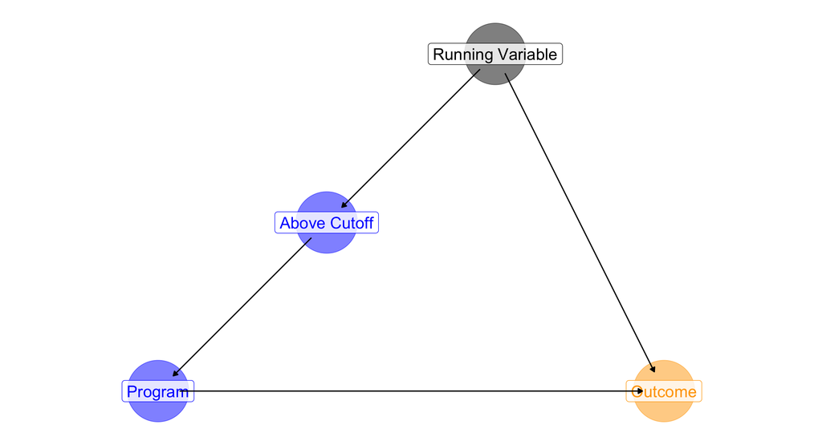

**Key assumption**: Potential outcomes (Y(0), Y(1)) are **continuous** in the running variable at the cutoff.

- In other words: People just above and just below are basically alike.
- If the program didn’t exist, their average outcomes would change smoothly with the score—no sudden jump right at the threshold.

## RDD

| Student ID | Entrance Score | Tutor Assigned? | Exit Exam (illustrative) |
| --- | --- | --- | --- |
| 201 | 68.0 | Yes | 74.0 |
| 202 | 69.5 | Yes | 74.8 |
| 203 | 70.0 | Yes | 75.0 |
| 204 | 70.2 | No | 65.1 |
| 205 | 71.0 | No | 65.5 |
| 206 | 72.3 | No | 66.2 |

## RDD

### Hypothetical tutoring program

Students take an entrance exam

Those who score 70 or lower get a free tutor for the year

Students then take an exit exam at the end of the year

## RDD

### Hypothetical tutoring program

```r
# Fake program data
set.seed(1234)   # makes the random numbers repeatable (so results are the same each time)
num_students <- 1000

tutoring <- tibble(
  id = 1:num_students,  # create 1000 students, each with a unique id

  # entrance exam scores: drawn from a beta distribution (skewed toward higher scores)
  entrance_exam = rbeta(num_students, shape1 = 7, shape2 = 2),

  # exit exam base scores: drawn from another beta distribution
  exit_exam = rbeta(num_students, shape1 = 5, shape2 = 3)
) |>
  mutate(
    # scale entrance exam from 0–1 to 0–100 to make it look like a real exam score
    entrance_exam = entrance_exam * 100,

    # assign tutoring: students with entrance exam ≤ 70 get a tutor
    tutoring = entrance_exam <= 70
  ) |>
  mutate(
    # create final exit exam scores:
    # start with a base (exit_exam * 40),
    # add +10 points if the student had tutoring,
    # and add a benefit from prior knowledge (half of entrance score)
    exit_exam = exit_exam * 40 + 10 * tutoring + entrance_exam / 2
  ) |>
  mutate(
    # introduce some “fuzziness” (real life isn’t perfect!)
    # for students with entrance exam between 60 and 80,
    # randomly decide whether they got tutoring or not
    tutoring_fuzzy = ifelse(
      entrance_exam > 60 & entrance_exam < 80,
      sample(c(TRUE, FALSE), n(), replace = TRUE),
      tutoring
    )
  ) |>
  mutate(
    # create nice text labels for charts and tables
    tutoring_text = factor(
      tutoring,
      levels = c(FALSE, TRUE),
      labels = c("No tutor", "Tutor")
    ),
    tutoring_fuzzy_text = factor(
      tutoring_fuzzy,
      levels = c(FALSE, TRUE),
      labels = c("No tutor", "Tutor")
    )
  ) |>
  mutate(
    # center the entrance exam around 70 (the cutoff)
    # so 0 = exactly at the tutoring rule
    entrance_centered = entrance_exam - 70
  )
```

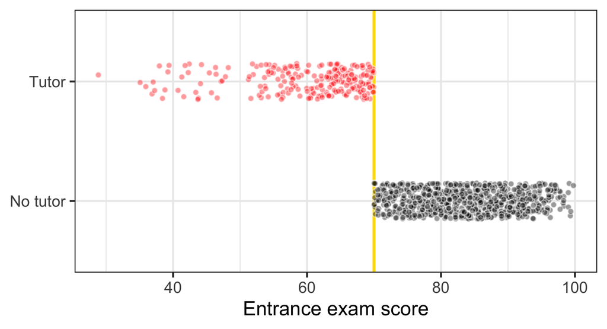

```r
ggplot(tutoring, aes(x = entrance_exam, y = tutoring_text, fill = tutoring_text)) +
  geom_vline(xintercept = 70, linewidth = 2, color = "#FFDC00") +
  geom_point(size = 3, pch = 21, color = "white", alpha = 0.4,
             position = position_jitter(width = 0, height = 0.15, seed = 1234)) +
  labs(x = "Entrance exam score", y = NULL) +
  guides(fill = "none") +
  scale_fill_manual(values = c("black", "red"), name = NULL) +
  theme_bw(base_size = 28)
```

## Intuition

### Hypothetical tutoring program

The people right before and right after the threshold are very similar

The idea is that we can measure the effect of the program by examining students just around the threshold

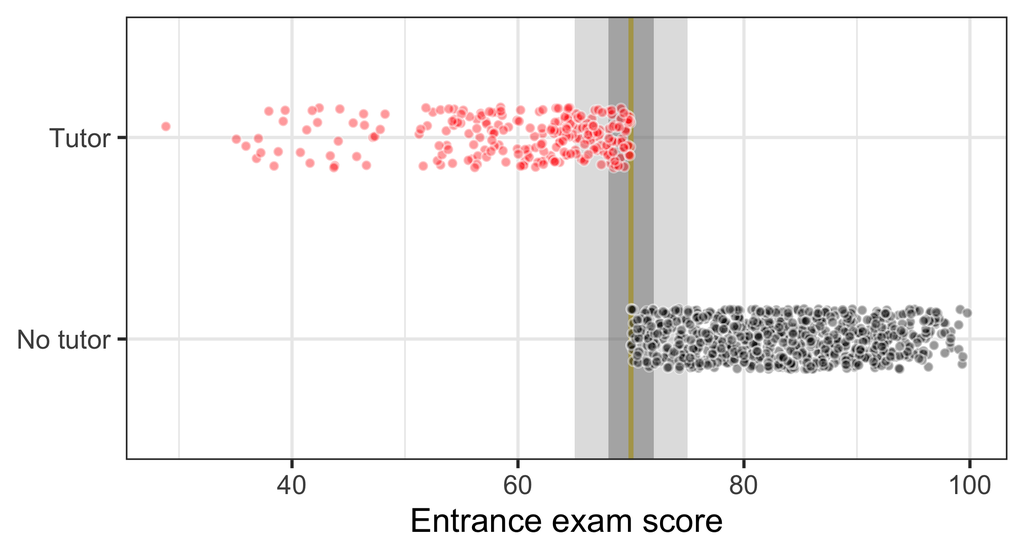

```r
ggplot(tutoring, aes(x = entrance_exam, y = tutoring_text, fill = tutoring_text)) +
  geom_vline(xintercept = 70, linewidth = 2, color = "#FFDC00") +
    annotate(geom = "rect", fill = "grey50", alpha = 0.25, ymin = -Inf, ymax = Inf,
           xmin = 70 - 5,  xmax = 70 + 5) +
    annotate(geom = "rect", fill = "grey50", alpha = 0.5, ymin = -Inf, ymax = Inf,
           xmin = 70 - 2,  xmax = 70 + 2) +
  geom_point(size = 3, pch = 21, color = "white", alpha = 0.4,
             position = position_jitter(width = 0, height = 0.15, seed = 1234)) +
  labs(x = "Entrance exam score", y = NULL) +
  guides(fill = "none") +
  scale_fill_manual(values = c("black", "red"), name = NULL) +
  theme_bw(base_size = 28)
```

## Intuition

### Hypothetical tutoring program

The people right before and right after the threshold are very similar

The idea is that we can measure the effect of the program by examining students just around the threshold.

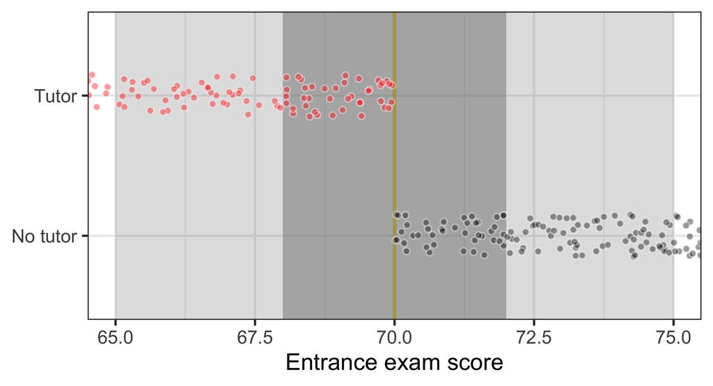

```r
ggplot(tutoring, aes(x = entrance_exam, y = tutoring_text, fill = tutoring_text)) +
  geom_vline(xintercept = 70, linewidth = 2, color = "#FFDC00") +
    annotate(geom = "rect", fill = "grey50", alpha = 0.25, ymin = -Inf, ymax = Inf,
           xmin = 70 - 5,  xmax = 70 + 5) +
    annotate(geom = "rect", fill = "grey50", alpha = 0.5, ymin = -Inf, ymax = Inf,
           xmin = 70 - 2,  xmax = 70 + 2) +
  geom_point(size = 3, pch = 21, color = "white", alpha = 0.4,
             position = position_jitter(width = 0, height = 0.15, seed = 1234)) +
  labs(x = "Entrance exam score", y = NULL) +
  guides(fill = "none") +
  scale_fill_manual(values = c("black", "red"), name = NULL) +
  theme_bw(base_size = 28)+
    coord_cartesian(xlim = c(70 - 5, 70 + 5))
```

## Intuition

### Hypothetical tutoring program

Relationship between entrance and exit exam scores, by tutoring status.

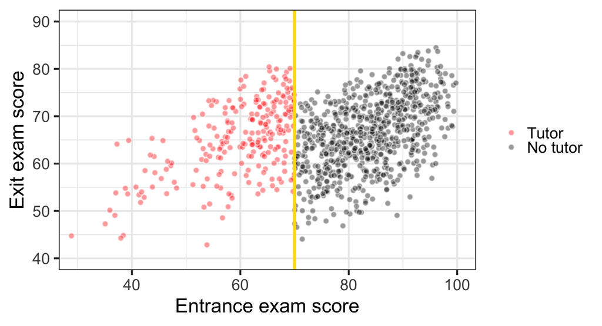

```r
ggplot(tutoring, aes(x = entrance_exam, y = exit_exam, fill = tutoring_text)) +
  geom_point(size = 3, pch = 21, color = "white", alpha = 0.4)+
  geom_vline(xintercept = 70, size = 2, color = "#FFDC00") +
  labs(x = "Entrance exam score", y = "Exit exam score") +
  #guides(fill = "none") +
    guides(fill = guide_legend(reverse = TRUE)) +
  scale_fill_manual(values = c("black", "red"), name = NULL) +
  theme_bw(base_size = 28)+
  coord_cartesian(xlim = c(30, 100),
           ylim = c(40, 90))
```

## Intuition

### Hypothetical tutoring program

Relationship between entrance and exit exam scores, by tutoring status.

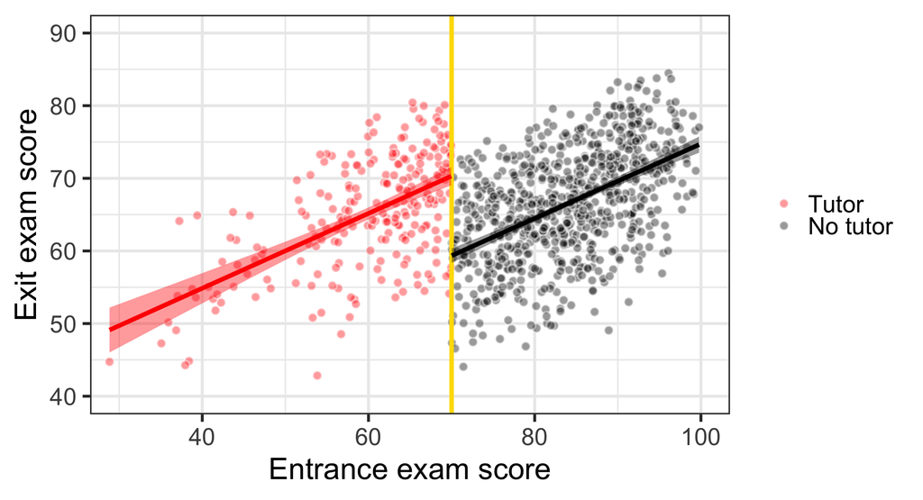

```r
ggplot(tutoring, aes(x = entrance_exam, y = exit_exam, fill = tutoring_text)) +
  geom_point(size = 3, pch = 21, color = "white", alpha = 0.4)+
  geom_vline(xintercept = 70, size = 2, color = "#FFDC00") +
  labs(x = "Entrance exam score", y = "Exit exam score") +
  #guides(fill = "none") +
    guides(fill = guide_legend(reverse = TRUE)) +
  geom_smooth(data = filter(tutoring, entrance_exam <= 70),
              method = "lm",
              color="red",
              #aes(color = tutoring_text),
              size = 2, show.legend = FALSE) +
  geom_smooth(data = filter(tutoring, entrance_exam > 70),
              method = "lm",
              color="black",
              #aes(color = tutoring_text),
              size = 2, show.legend = FALSE) +
    scale_fill_manual(values = c("black", "red"), name = NULL) +
  scale_color_manual(values = c("black", "red")) +
  theme_bw(base_size = 28)+
coord_cartesian(xlim = c(30, 100),
           ylim = c(40, 90))
```

## Intuition

### Hypothetical tutoring program

Relationship between entrance and exit exam scores, by tutoring status.

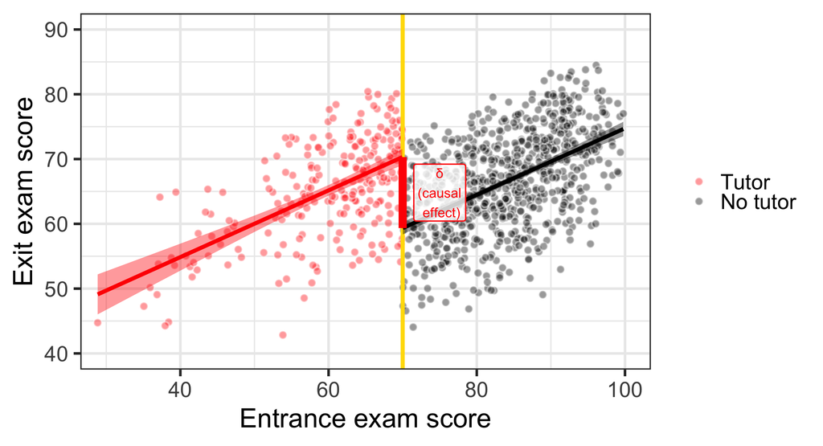

```r
library("broom")
tutoring <- tutoring |>
  mutate(tutoring = relevel(factor(tutoring), ref = "TRUE"))  # "TRUE" = treated is reference

rdd_tutoring <- lm(exit_exam ~ entrance_centered + tutoring, data = tutoring) |>
  tidy()

effect_control <- filter(rdd_tutoring, term == "(Intercept)")$estimate
late <- filter(rdd_tutoring, term == "tutoringFALSE")$estimate
effect_treatment <- effect_control + late


ggplot(tutoring, aes(x = entrance_exam, y = exit_exam, fill = tutoring_text)) +
  geom_point(size = 3, pch = 21, color = "white", alpha = 0.4) +
  geom_vline(xintercept = 70, size = 2, color = "#FFDC00") +
  labs(x = "Entrance exam score", y = "Exit exam score") +
  #guides(fill = "none") +
    guides(fill = guide_legend(reverse = TRUE)) +
  geom_smooth(data = filter(tutoring, entrance_exam <= 70),
              method = "lm",
              color="red",
              #aes(color = tutoring_text),
              size = 2, show.legend = FALSE) +
  geom_smooth(data = filter(tutoring, entrance_exam > 70),
              method = "lm",
              color="black",
              #aes(color = tutoring_text),
              size = 2, show.legend = FALSE) +
  scale_fill_manual(values = c("black", "red"), name = NULL) +
  scale_color_manual(values = c("black", "red")) +
  theme_bw(base_size = 28)+
  annotate(geom = "segment", x = 70, xend = 70,
           y = effect_control, yend = effect_treatment,
           size = 4, color = "red") +
  annotate(geom = "label", x = 75, y = effect_treatment - (late / 2),
           label = "δ\n(causal\n effect)",
           size=5,
           color = "red", fill = alpha(c("white"),0.8))+
coord_cartesian(xlim = c(30, 100),
           ylim = c(40, 90))
```

## Intuition

### Hypothetical tutoring program

The $\delta$ measures the gap in outcome for people on both sides of the cutpoint.

**Sharp RD**, $\delta$ - **local average treatment effect (ATE) at the cutoff**.  
**Fuzzy RD**, $\delta$ - **local average treatment effect for compliers (LATE) at the cutoff**.

## Intuition

### Hypothetical tutoring program

The size of the gap depends on how you fit the functions on each side of the cutoff

The type of lines you choose can change the estimate of $\delta$

- parametric vs. non-parametric
- bandwidths
- kernels

## Intuition

### Hypothetical tutoring program

Relationship between entrance and exit exam scores, by tutoring status.

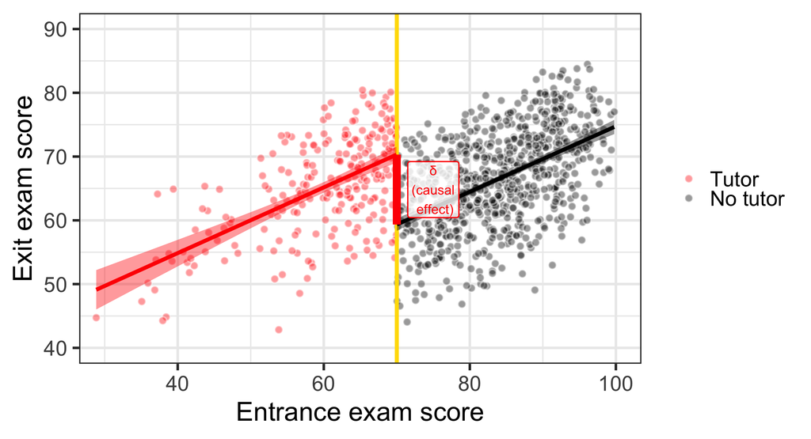

```r
ggplot(tutoring, aes(x = entrance_exam, y = exit_exam, fill = tutoring_text)) +
  geom_point(size = 3, pch = 21, color = "white", alpha = 0.4) +
  geom_vline(xintercept = 70, size = 2, color = "#FFDC00") +
  labs(x = "Entrance exam score", y = "Exit exam score") +
  #guides(fill = "none") +
    guides(fill = guide_legend(reverse = TRUE)) +
  geom_smooth(data = filter(tutoring, entrance_exam <= 70),
              method = "lm",
              color="red",
              #aes(color = tutoring_text),
              size = 2, show.legend = FALSE) +
  geom_smooth(data = filter(tutoring, entrance_exam > 70),
              method = "lm",
              color="black",
              #aes(color = tutoring_text),
              size = 2, show.legend = FALSE) +
  scale_fill_manual(values = c("black", "red"), name = NULL) +
  scale_color_manual(values = c("black", "red")) +
  theme_bw(base_size = 28)+
  annotate(geom = "segment", x = 70, xend = 70,
           y = effect_control, yend = effect_treatment,
           size = 4, color = "red") +
  annotate(geom = "label", x = 75, y = effect_treatment - (late / 2),
           label = "δ\n(causal\n effect)",
           size=5,
           color = "red", fill = alpha(c("white"),0.8))+
coord_cartesian(xlim = c(30, 100),
           ylim = c(40, 90))
```

## Intuition

### Hypothetical tutoring program

Relationship between entrance and exit exam scores, by tutoring status.

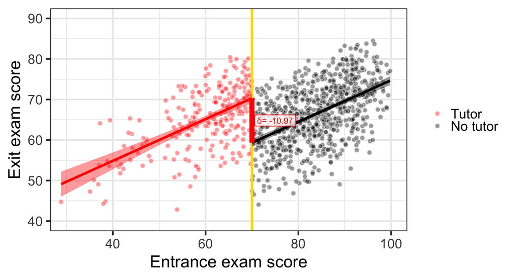

```r
program_data <- tutoring %>%
  mutate(entrance_centered =
           entrance_exam - 70)
model1 <- lm(exit_exam ~
               entrance_centered + tutoring,
             data = program_data)

x<-tidy(model1)
late<-round(x$estimate[x$term=="tutoringFALSE"],2)
const<-round(x$estimate[x$term=="(Intercept)"],2)


ggplot(tutoring, aes(x = entrance_exam, y = exit_exam, fill = tutoring_text)) +
  geom_point(size = 3, pch = 21, color = "white", alpha = 0.4) +
  geom_vline(xintercept = 70, size = 2, color = "#FFDC00") +
  labs(x = "Entrance exam score", y = "Exit exam score") +
  #guides(fill = "none") +
    guides(fill = guide_legend(reverse = TRUE)) +
  geom_smooth(data = filter(tutoring, entrance_exam <= 70),
              method = "lm",
              color="red",
              #aes(color = tutoring_text),
              size = 2, show.legend = FALSE) +
  geom_smooth(data = filter(tutoring, entrance_exam > 70),
              method = "lm",
              color="black",
              #aes(color = tutoring_text),
              size = 2, show.legend = FALSE) +
  scale_fill_manual(values = c("black", "red"), name = NULL) +
  scale_color_manual(values = c("black", "red")) +
  theme_bw(base_size = 28)+
  annotate(geom = "segment", x = 70, xend = 70,
           y = effect_control, yend = effect_treatment,
           size = 4, color = "red") +
  annotate(geom = "label", x = 75, y = const + (late / 2),
           label = paste("δ=", late),
           size=5,
           color = "red", fill = alpha(c("white"),0.8))+
coord_cartesian(xlim = c(30, 100),
           ylim = c(40, 90))
```

## Intuition

### Hypothetical tutoring program

Relationship between entrance and exit exam scores, by tutoring status.

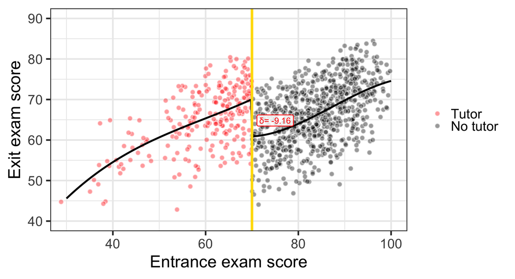

```r
# 1. Fit cubic models
fit_control <- lm(exit_exam ~ poly(entrance_exam, 3, raw = TRUE),
                  data = filter(tutoring, entrance_exam < 70))

fit_treat <- lm(exit_exam ~ poly(entrance_exam, 3, raw = TRUE),
                data = filter(tutoring, entrance_exam >= 70))

# 2. Get tidy versions
tidy_control <- tidy(fit_control)
tidy_treat <- tidy(fit_treat)

cutoff <- 70
effect_control <- predict(fit_control, newdata = data.frame(entrance_exam = cutoff))
effect_treatment <- predict(fit_treat, newdata = data.frame(entrance_exam = cutoff))
delta <- round(effect_treatment-effect_control, 2)


# Create prediction data for plotting
x_vals <- tibble(entrance_exam = seq(30, 100, length.out = 300))

preds <- x_vals %>%
  mutate(
    exit_exam = ifelse(
      entrance_exam < 70,
      predict(fit_control, newdata = x_vals),
      predict(fit_treat, newdata = x_vals)
    )
  )

ggplot(tutoring, aes(x = entrance_exam, y = exit_exam, fill = tutoring_text)) +
  geom_point(size = 3, pch = 21, color = "white", alpha = 0.4) +
  geom_line(data = preds, aes(x = entrance_exam, y = exit_exam),
            inherit.aes = FALSE, color = "black", size = 1.5) +
  geom_vline(xintercept = 70, color = "#FFDC00", size = 2) +
  theme_bw(base_size = 28)+
scale_fill_manual(values = c("Tutor" = "red", "No tutor" = "black"), name = NULL,
                  guide = guide_legend(reverse = TRUE))+
  labs(x = "Entrance exam score", y = "Exit exam score")+
    annotate(geom = "label", x = 75, y = const + (late / 2),
           label = paste("δ=", delta),
           size=5,
           color = "red", fill = alpha(c("white"),0.8))+
    coord_cartesian(xlim = c(30, 100),
           ylim = c(40, 90))+
      guides(fill = guide_legend(reverse = TRUE))
```

## Intuition

### Hypothetical tutoring program

Relationship between entrance and exit exam scores, by tutoring status.

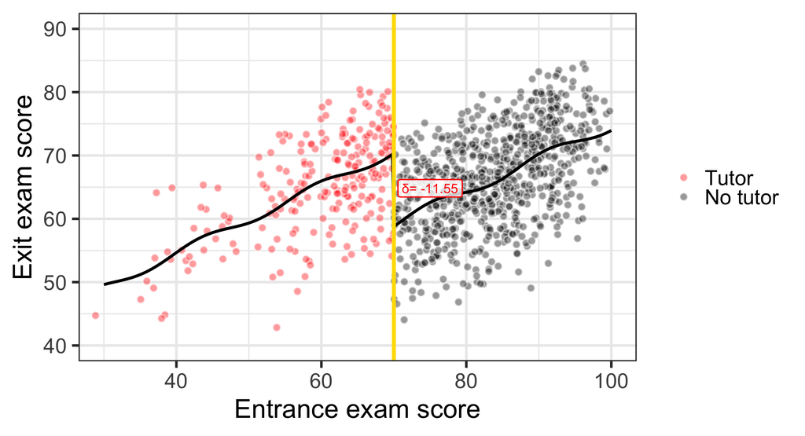

```r
library(dplyr)

# Add sine-transformed variable
tutoring <- tutoring |>
  mutate(sin_term = sin(0.2 * entrance_exam))

# Control group: entrance_exam < 70
fit_trig_control <- nls(
  exit_exam ~ a + b * entrance_exam + c * sin(d * entrance_exam),
  data = filter(tutoring, entrance_exam < 70),
  start = list(a = 55, b = 0.4, c = 15, d = 0.4)
)

# Treatment group: entrance_exam >= 70
fit_trig_treat <- nls(
  exit_exam ~ a + b * entrance_exam + c * sin(d * entrance_exam),
  data = filter(tutoring, entrance_exam >= 70),
  start = list(a = 55, b = 0.4, c = 15, d = 0.4)
)

x_vals <- tibble(entrance_exam = seq(30, 100, length.out = 300))

preds_trig <- x_vals |>
  mutate(
    exit_exam = ifelse(
      entrance_exam < 70,
      predict(fit_trig_control, newdata = x_vals),
      predict(fit_trig_treat, newdata = x_vals)
    )
  )

cutoff <- 70

# Create a new data frame for x = 70
cutoff_df <- data.frame(entrance_exam = cutoff)

# Predicted outcome from each model
effect_control <- predict(fit_trig_control, newdata = cutoff_df)
effect_treatment <- predict(fit_trig_treat, newdata = cutoff_df)

# Compute the treatment effect (jump at cutoff)
delta <- round(effect_treatment-effect_control,2)

ggplot(tutoring, aes(x = entrance_exam, y = exit_exam, fill = tutoring_text)) +
  geom_point(size = 3, pch = 21, color = "white", alpha = 0.4) +
  geom_line(data = preds_trig, aes(x = entrance_exam, y = exit_exam),
            inherit.aes = FALSE, color = "black", size = 1.5) +
  geom_vline(xintercept = 70, color = "#FFDC00", size = 2) +
  theme_bw(base_size = 28)+
scale_fill_manual(values = c("Tutor" = "red", "No tutor" = "black"), name = NULL,
                  guide = guide_legend(reverse = TRUE))+
  labs(x = "Entrance exam score", y = "Exit exam score")+
    annotate(geom = "label", x = 75, y = const + (late / 2),
           label = paste("δ=", delta),
           size=5,
           color = "red", fill = alpha(c("white"),0.8))+
      coord_cartesian(xlim = c(30, 100),
           ylim = c(40, 90))+
      guides(fill = guide_legend(reverse = TRUE))
```

## Lines and Fit

Parametric line should fit the data pretty well

Non-parametric lines use the data to find the best line, often with windows and moving averages.

For example, one common method is LOESS (Locally Estimated Scatterplot Smoothing)

## Measuring the Gap Parametrically

The gap can be easily measured by centering the running variable around the threshold:

- redefining the variable so that the cutoff equals zero.

```r
head(tutoring, 5)
```

| id | entrance_exam | exit_exam | tutoring | tutoring_fuzzy | tutoring_text | tutoring_fuzzy_text | entrance_centered | sin_term |
| --- | --- | --- | --- | --- | --- | --- | --- | --- |
| 1 | 92.40833 | 78.07592 | FALSE | FALSE | No tutor | No tutor | 22.4083252 | -0.3596482 |
| 2 | 72.77238 | 58.21757 | FALSE | FALSE | No tutor | No tutor | 2.7723797 | 0.9141829 |
| 3 | 53.65090 | 61.96543 | TRUE | TRUE | Tutor | Tutor | -16.3491016 | -0.9649891 |
| 4 | 98.32688 | 67.48956 | FALSE | FALSE | No tutor | No tutor | 28.3268829 | 0.7282882 |
| 5 | 69.71219 | 54.12888 | TRUE | TRUE | Tutor | Tutor | -0.2878064 | 0.9811003 |

$$y = \beta_0 + \beta_1 \text{Running Variable (centered)} + \beta_2 \text{Treatment}$$

## Measuring the Gap Parametrically

And this is how we can display the results

```r
library(modelsummary)
program_data <- tutoring |>
  mutate(entrance_centered =
           entrance_exam - 70)

#Running model
model1 <- lm(exit_exam ~  entrance_centered + tutoring, data = program_data)

#Make table
modelsummary(model1, stars = TRUE, gof_map = c("nobs", "r.squared"))
```

|  | (1) |
| --- | --- |
| (Intercept) | 70.306*** |
|  | (0.501) |
| entrance_centered | 0.514*** |
|  | (0.027) |
| tutoringFALSE | -10.968*** |
|  | (0.802) |
| Num.Obs. | 1000 |
| R2 | 0.273 |

+ p < 0.1, * p < 0.05, ** p < 0.01, *** p < 0.001

## Measuring the Gap Parametrically

And this is how we can display the results

```r
library(modelsummary)
program_data <- tutoring |>
  mutate(entrance_centered =
           entrance_exam - 70)

#Running model
model1 <- lm(exit_exam ~  entrance_centered + tutoring, data = program_data)

#Make table
modelsummary(model1, stars = TRUE, gof_map = c("nobs", "r.squared"))
```

|  | (1) |
| --- | --- |
| (Intercept) | 70.306*** |
|  | (0.501) |
| entrance_centered | 0.514*** |
|  | (0.027) |
| tutoringFALSE | -10.968*** |
|  | (0.802) |
| Num.Obs. | 1000 |
| R2 | 0.273 |

+ p < 0.1, * p < 0.05, ** p < 0.01, *** p < 0.001

Interpretation:

- **entrance_centered**: For each 1-point increase in entrance score, the exit exam score increases by 0.514 points, holding tutoring status constant.
- **tutoringFALSE**: Students without tutoring score on average 10.97 points lower on the exit exam, holding entrance scores constant.

## Measuring the Gap Parametrically

And this is how we can display the results on the graph

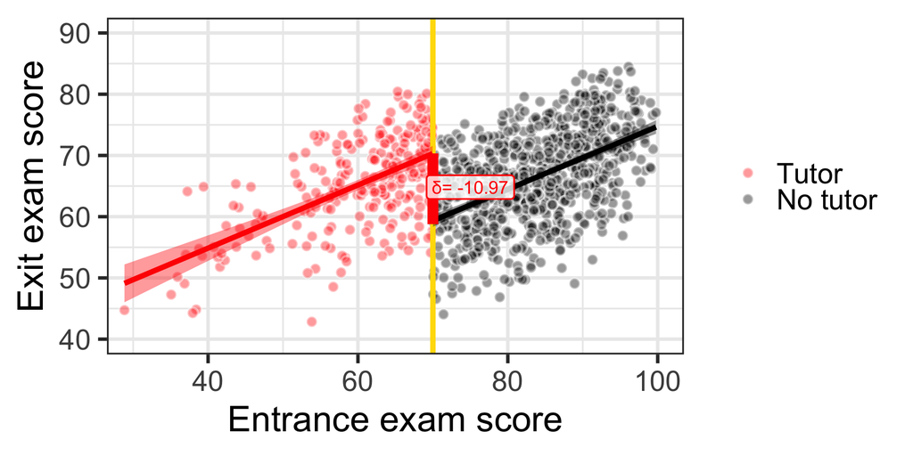

```r
x<-tidy(model1)
gap<-round(x$estimate[x$term=="tutoringFALSE"],2)
const<-round(x$estimate[x$term=="(Intercept)"],2)

ggplot(tutoring, aes(x = entrance_exam, y = exit_exam, fill = tutoring_text)) +
  geom_point(size = 3, pch = 21, color = "white", alpha = 0.4) +
  geom_vline(xintercept = 70, size = 2, color = "#FFDC00") +
  labs(x = "Entrance exam score", y = "Exit exam score") +
  #guides(fill = "none") +
    guides(fill = guide_legend(reverse = TRUE)) +
  geom_smooth(data = filter(tutoring, entrance_exam <= 70),
              method = "lm",
              color="red",
              #aes(color = tutoring_text),
              size = 2, show.legend = FALSE) +
  geom_smooth(data = filter(tutoring, entrance_exam > 70),
              method = "lm",
              color="black",
              #aes(color = tutoring_text),
              size = 2, show.legend = FALSE) +
  scale_fill_manual(values = c("black", "red"), name = NULL) +
  scale_color_manual(values = c("black", "red")) +
  theme_bw(base_size = 28)+
  annotate(geom = "segment", x = 70, xend = 70,
           y = effect_control, yend = effect_treatment,
           size = 4, color = "red") +
  annotate(geom = "label", x = 75, y = const + (late / 2),
           label = paste("δ=", gap),
           size=5,
           color = "red", fill = alpha(c("white"),0.8))+
coord_cartesian(xlim = c(30, 100),
           ylim = c(40, 90))
```

## Measuring the Gap Nonparametrically

We need to calculate the gap nonparametrically using `rdrobust`

```r
library(rdrobust)
rd_out <- rdrobust(y = tutoring$exit_exam,
                   x = tutoring$entrance_exam,
                   c = 70)

#summary(rd_out)
#Extracting conventional coefficient
gap_rdrobust<-rd_out$coef["Conventional", "Coeff"]
```

## Measuring the Gap Nonparametrically

And this is how we can display the results on the graph

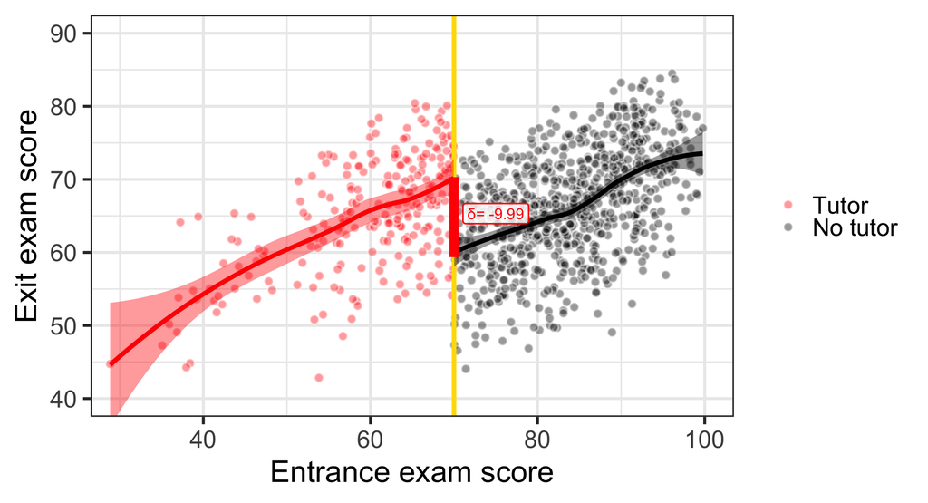

```r
model_control <- lm(exit_exam ~ entrance_exam,
                    data = filter(tutoring, entrance_exam <= 70))

model_treat <- lm(exit_exam ~ entrance_exam,
                  data = filter(tutoring, entrance_exam > 70))

effect_control <- predict(model_control, newdata = data.frame(entrance_exam = 70))
effect_treatment <- predict(model_treat, newdata = data.frame(entrance_exam = 70))

late <- round(gap_rdrobust,2)

ggplot(tutoring, aes(x = entrance_exam, y = exit_exam, fill = tutoring_text)) +
  geom_point(size = 3, pch = 21, color = "white", alpha = 0.4) +
  geom_vline(xintercept = 70, size = 2, color = "#FFDC00") +
  labs(x = "Entrance exam score", y = "Exit exam score") +
  #guides(fill = "none") +
    guides(fill = guide_legend(reverse = TRUE)) +
  geom_smooth(data = filter(tutoring, entrance_exam <= 70),
              method = "loess",
              color="red",
              #aes(color = tutoring_text),
              size = 2, show.legend = FALSE) +
  geom_smooth(data = filter(tutoring, entrance_exam > 70),
              method = "loess",
              color="black",
              #aes(color = tutoring_text),
              size = 2, show.legend = FALSE) +
  scale_fill_manual(values = c("black", "red"), name = NULL) +
  scale_color_manual(values = c("black", "red")) +
  theme_bw(base_size = 28)+
  annotate(geom = "segment", x = 70, xend = 70,
           y = effect_control, yend = effect_treatment,
           size = 4, color = "red") +
    annotate(geom = "label", x = 75, y = const + (late / 2),
           label = paste("δ=", late),
           size=5,
           color = "red", fill = alpha(c("white"),0.8))+
coord_cartesian(xlim = c(30, 100),
           ylim = c(40, 90))
```

## Bandwidths

What we care about is the area right around the cutoff.

The observations far away do not matter because they are too different and thus, they are not comparable

That is why we need to focus on bandwidth or the window around cutoff

## Bandwidths

These are the observations within a 5-point bandwidth

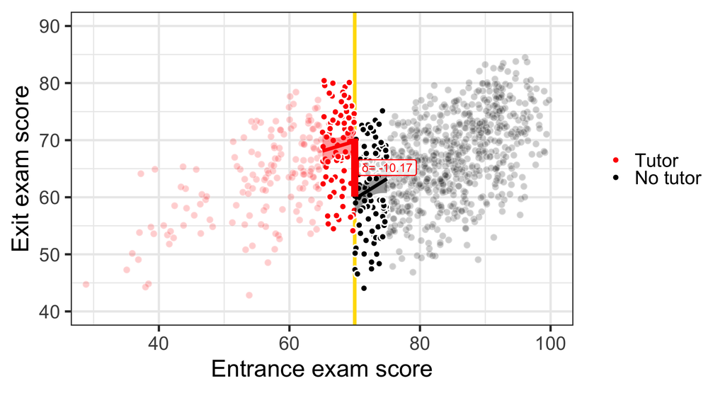

```r
#Marking obs. within a 5-point bandwidth
tutoring <- tutoring %>%
  mutate(
    in_bw_5 = abs(entrance_exam - 70) <= 5,
    in_bw_10 = abs(entrance_exam - 70) <= 10
  )


#Running model
program_data_bw_5<-subset(tutoring, in_bw_5==TRUE)
model2 <- lm(exit_exam ~  entrance_centered + tutoring, data = program_data_bw_5)

x<-tidy(model2)
gap<-round(x$estimate[x$term=="tutoringFALSE"],2)
const<-round(x$estimate[x$term=="(Intercept)"],2)


ggplot(tutoring, aes(x = entrance_exam, y = exit_exam, fill = tutoring_text)) +
  geom_point(size = 3, pch = 21, color = "white", alpha = 0.2) +
  geom_vline(xintercept = 70, size = 2, color = "#FFDC00") +
  labs(x = "Entrance exam score", y = "Exit exam score") +
  #guides(fill = "none") +
    guides(fill = guide_legend(reverse = TRUE)) +
  theme_bw(base_size = 28)+
    geom_point(data = filter(tutoring, in_bw_5),
           aes(x = entrance_exam, y = exit_exam),
           size = 3, pch = 21, color = "white", alpha = 1)+
geom_smooth(data = filter(tutoring, in_bw_5 & entrance_exam <= 70),
            method = "lm",
            color = "red",
            size = 2,
            show.legend = FALSE) +
geom_smooth(data = filter(tutoring, in_bw_5 & entrance_exam > 70),
            method = "lm",
            color = "black",
            size = 2,
            show.legend = FALSE)+
  scale_fill_manual(values = c("black", "red"), name = NULL) +
  scale_color_manual(values = c("black", "red")) +
  annotate(geom = "segment", x = 70, xend = 70,
           y = const, yend = const + gap,
           size = 4, color = "red") +
    annotate(geom = "label", x = 75, y = const + (gap / 2),
           label = paste("δ=", gap),
           size=5,
           color = "red", fill = alpha(c("white"),0.8))+
coord_cartesian(xlim = c(30, 100),
           ylim = c(40, 90))
```

## Bandwidths

These are the observations within a 10-point bandwidth

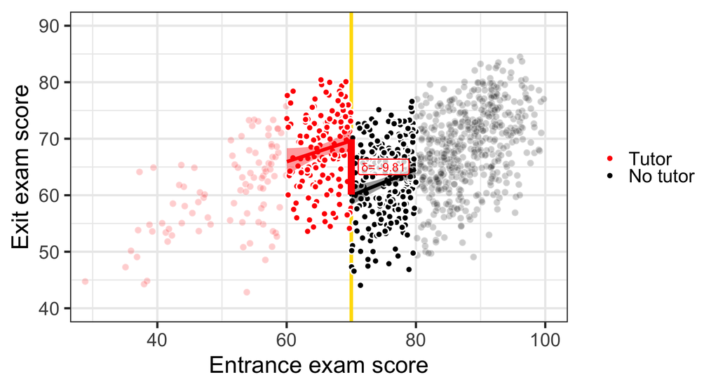

```r
#Running model
program_data_bw_10<-subset(tutoring, in_bw_10==TRUE)
model3 <- lm(exit_exam ~  entrance_centered + tutoring, data = program_data_bw_10)

x<-tidy(model3)
gap<-round(x$estimate[x$term=="tutoringFALSE"],2)
const<-round(x$estimate[x$term=="(Intercept)"],2)


ggplot(tutoring, aes(x = entrance_exam, y = exit_exam, fill = tutoring_text)) +
  geom_point(size = 3, pch = 21, color = "white", alpha = 0.2) +
  geom_vline(xintercept = 70, size = 2, color = "#FFDC00") +
  labs(x = "Entrance exam score", y = "Exit exam score") +
  #guides(fill = "none") +
    guides(fill = guide_legend(reverse = TRUE)) +
  scale_fill_manual(values = c("black", "red"), name = NULL) +
  scale_color_manual(values = c("black", "red")) +
  theme_bw(base_size = 28)+
    geom_point(data = filter(tutoring, in_bw_10),
           aes(x = entrance_exam, y = exit_exam),
           size = 3, pch = 21, color = "white", alpha = 1)+
  geom_smooth(data = filter(tutoring, in_bw_10 & entrance_exam <= 70),
            method = "lm",
            color = "red",
            size = 2,
            show.legend = FALSE) +
geom_smooth(data = filter(tutoring, in_bw_10 & entrance_exam > 70),
            method = "lm",
            color = "black",
            size = 2,
            show.legend = FALSE)+
  annotate(geom = "segment", x = 70, xend = 70,
           y = const, yend = const + gap,
           size = 4, color = "red") +
    annotate(geom = "label", x = 75, y = const + (gap / 2),
           label = paste("δ=", gap),
           size=5,
           color = "red", fill = alpha(c("white"),0.8))+
coord_cartesian(xlim = c(30, 100),
           ylim = c(40, 90))
```

## Bandwidths

### Optimal Bandwidth

But which ones do we choose?

The `rdrobust` package allows us to decide on the bandwidth:

```r
rd_out <- rdrobust(y = tutoring$exit_exam,
                   x = tutoring$entrance_exam,
                   c = 70)

bw_opt <- rd_out$bws[1]  # optimal bandwidth for conventional estimate
bw_opt
```

```
[1] 7.615756
```

## Bandwidths

### Optimal Bandwidth

These are the results using the 7.62 bandwidth.

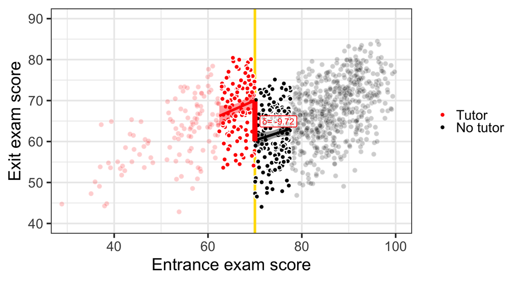

```r
#Running model
program_data_opt<-subset(tutoring, abs(entrance_centered)<bw_opt)
model4 <- lm(exit_exam ~  entrance_centered + tutoring, data = program_data_opt)

x<-tidy(model4)
gap<-round(x$estimate[x$term=="tutoringFALSE"],2)
const<-round(x$estimate[x$term=="(Intercept)"],2)


ggplot(tutoring, aes(x = entrance_exam, y = exit_exam, fill = tutoring_text)) +
  geom_point(size = 3, pch = 21, color = "white", alpha = 0.2) +
  geom_vline(xintercept = 70, size = 2, color = "#FFDC00") +
  labs(x = "Entrance exam score", y = "Exit exam score") +
  #guides(fill = "none") +
    guides(fill = guide_legend(reverse = TRUE)) +
  scale_fill_manual(values = c("black", "red"), name = NULL) +
  scale_color_manual(values = c("black", "red")) +
  theme_bw(base_size = 28)+
    geom_point(data = program_data_opt,
           aes(x = entrance_exam, y = exit_exam),
           size = 3, pch = 21, color = "white", alpha = 1)+
    geom_smooth(data = filter(program_data_opt, entrance_exam <= 70),
              method = "lm",
              color = "red",
              size = 2,
              show.legend = FALSE) +
  geom_smooth(data = filter(program_data_opt, entrance_exam > 70),
              method = "lm",
              color = "black",
              size = 2,
              show.legend = FALSE) +
  annotate(geom = "segment", x = 70, xend = 70,
           y = const, yend = const + gap,
           size = 4, color = "red") +
    annotate(geom = "label", x = 75, y = const + (gap / 2),
           label = paste("δ=", gap),
           size=5,
           color = "red", fill = alpha(c("white"),0.8))+
coord_cartesian(xlim = c(30, 100),
           ylim = c(40, 90))
```

## Bandwidths

It’s a good idea to have multiple bandwidths

- some that make sense
- some that are decided by the optimal bandwidth algorithm

You could use either a table or a graph.

## Kernel

The other important part of RD is choosing the kernel

**Kernel** = method for assigning importance to observations based on distance to the cutoff

## Bandwidths

### Kernel: Uniform

```r
library(ggnewscale)
# Define the boxcar (uniform) kernel function
rec <- function(x) (abs(x) <= 1) * 0.5

# Set cutoff and bandwidth
cutoff <- 70
bandwidth <- 40

# For rectangular kernel overlay
kernel_df <- data.frame(
  entrance_exam = seq(cutoff - bandwidth - 10, cutoff + bandwidth + 10, length.out = 200)
)
kernel_df$u <- (kernel_df$entrance_exam - cutoff) / bandwidth
kernel_df$boxcar_weight <- rec(kernel_df$u)
kernel_df$boxcar_weight_rescaled <- kernel_df$boxcar_weight * 50 + 40  # visual rescaling

# Apply kernel weights to main data
tutoring$boxcar_weight <- with(tutoring, {
  u <- (entrance_exam - cutoff) / bandwidth
  rec(u)
})

# Run weighted regression
model4 <- lm(exit_exam ~ entrance_centered + tutoring,
             data = tutoring,
             weights = boxcar_weight)

x <- tidy(model4)
gap <- round(x$estimate[x$term == "tutoringFALSE"], 2)
const <- round(x$estimate[x$term == "(Intercept)"], 2)

# Plot with rectangular kernel overlay
ggplot() +
  geom_point(data = tutoring,
             aes(x = entrance_exam,
                 y = exit_exam,
                 fill = tutoring_text,
                 size = boxcar_weight),
             shape = 21,
             alpha = 0.2) +
  geom_vline(xintercept = 70, size = 2, color = "#FFDC00") +
  labs(x = "Entrance exam score", y = "Exit exam score") +
  geom_smooth(
    data = filter(tutoring, entrance_exam <= 70),
    aes(x = entrance_exam, y = exit_exam),
    method = "lm",
    color = alpha("red", 0.2),
    fill = alpha("red", 0.2),
    size = 2,
    show.legend = FALSE
  ) +
  geom_smooth(
    data = filter(tutoring, entrance_exam > 70),
    aes(x = entrance_exam, y = exit_exam),
    method = "lm",
    color = alpha("black", 0.2),
    fill = alpha("black", 0.2),
    alpha = 0.2,
    size = 2,
    show.legend = FALSE
  ) +
  scale_fill_manual(values = c("black", "red"), name = NULL) +
  scale_color_manual(values = c("black", "red")) +
  scale_size_continuous(name = "Uniform\nWeight", range = c(2, 6)) +
  theme_bw(base_size = 28) +
  coord_cartesian(xlim = c(20, 120), ylim = c(40, 90)) +
  new_scale_color() +

  # Rectangle-shaped kernel overlay using geom_segment()
  geom_segment(
    aes(x = cutoff - bandwidth, xend = cutoff + bandwidth,
        y = 0.5 * 50 + 40, yend = 0.5 * 50 + 40,
        color = "Uniform\nKernel"),
    size = 2
  ) +
  geom_segment(aes(x = cutoff - bandwidth, xend = cutoff - bandwidth,
                 y = 40, yend = 0.5 * 50 + 40),
             color = "blue", size = 1) +
  geom_segment(aes(x = cutoff + bandwidth, xend = cutoff + bandwidth,
                 y = 40, yend = 0.5 * 50 + 40),
             color = "blue", size = 1)+

  scale_color_manual(name = NULL, values = c("Uniform\nKernel" = "blue"))+
    annotate(geom = "segment", x = 70, xend = 70,
           y = const, yend = const + gap,
           size = 4, color = "red") +
  annotate(geom = "label", x = 75, y = const + (gap / 2),
           label = paste("δ=", gap),
           size = 5,
           color = "red", fill = alpha("white", 0.8))+
    guides(
  size = guide_legend(order = 1),
  fill = guide_legend(order = 2),
  color = guide_legend(order = 3)
)
```

[figure not shown]

## Bandwidths

### Kernel: Triangular

```r
# Set cutoff and bandwidth
cutoff <- 70
bandwidth <- 40  # adjust as needed

# Create a data frame to draw the triangular kernel
kernel_df <- data.frame(
  entrance_exam = seq(cutoff - bandwidth, cutoff + bandwidth, length.out = 200)
)

# Triangular kernel weights for visualization
kernel_df$tri_weight <- with(kernel_df, {
  u <- (entrance_exam - cutoff) / bandwidth
  ifelse(abs(u) <= 1, 1 - abs(u), 0)
})

# Rescale for visual overlay
kernel_df$tri_weight_rescaled <- kernel_df$tri_weight * 50 + 40  # adjust scaling as needed

# Compute triangular weights in main dataset
tutoring$tri_weight <- with(tutoring, {
  u <- (entrance_exam - cutoff) / bandwidth
  ifelse(abs(u) <= 1, 1 - abs(u), 0)
})

# Run weighted regression using triangular kernel
model4 <- lm(exit_exam ~ entrance_centered + tutoring,
             data = tutoring,
             weights = tri_weight)

# Extract estimates for annotation
x <- tidy(model4)
gap <- round(x$estimate[x$term == "tutoringFALSE"], 2)
const <- round(x$estimate[x$term == "(Intercept)"], 2)


ggplot()+
  geom_point(data = tutoring,
             aes(x = entrance_exam,
                 y = exit_exam,
                 fill = tutoring_text,
                 size = tri_weight),
             shape = 21,
             alpha = 0.2) +
  geom_vline(xintercept = 70, size = 2, color = "#FFDC00") +
  labs(x = "Entrance exam score", y = "Exit exam score") +
geom_smooth(
  data = filter(tutoring, entrance_exam <= 70),
  aes(x = entrance_exam, y = exit_exam),
  method = "lm",
  color = alpha("red", 0.2),        # line color
  fill = alpha("red", 0.2),          # confidence interval fill
  size = 2,
  show.legend = FALSE
) +
geom_smooth(
  data = filter(tutoring, entrance_exam > 70),
  aes(x = entrance_exam, y = exit_exam),
  method = "lm",
  color = alpha("black", 0.2),        # line color
  fill = alpha("black", 0.2),          # confidence interval fill
  alpha = 0.2,
  size = 2,
  show.legend = FALSE
) +
  scale_fill_manual(values = c("black", "red"), name = NULL) +
  scale_color_manual(values = c("black", "red")) +
  scale_size_continuous(name = "Triangular\nWeight", range = c(2, 6)) +  # legend control
  theme_bw(base_size = 28)+
  annotate(geom = "segment", x = 70, xend = 70,
           y = const, yend = const + gap,
           size = 4, color = "red") +
    annotate(geom = "label", x = 75, y = const + (gap / 2),
           label = paste("δ=", gap),
           size=5,
           color = "red", fill = alpha(c("white"),0.8))+
  coord_cartesian(xlim = c(20, 120), ylim = c(40, 90)) +
  new_scale_color() +
  geom_line(
    data = kernel_df,
    aes(x = entrance_exam,
        y = tri_weight_rescaled,
        color = "Triangular\n Kernel"), # <-- also mapped to show dashed line in legend
    inherit.aes = FALSE,
    size = 2
  )+
  scale_color_manual(name = NULL, values = c("Triangular\n Kernel" = "blue"))+
    guides(
  size = guide_legend(order = 1),
  fill = guide_legend(order = 2),
  color = guide_legend(order = 3)
)
```

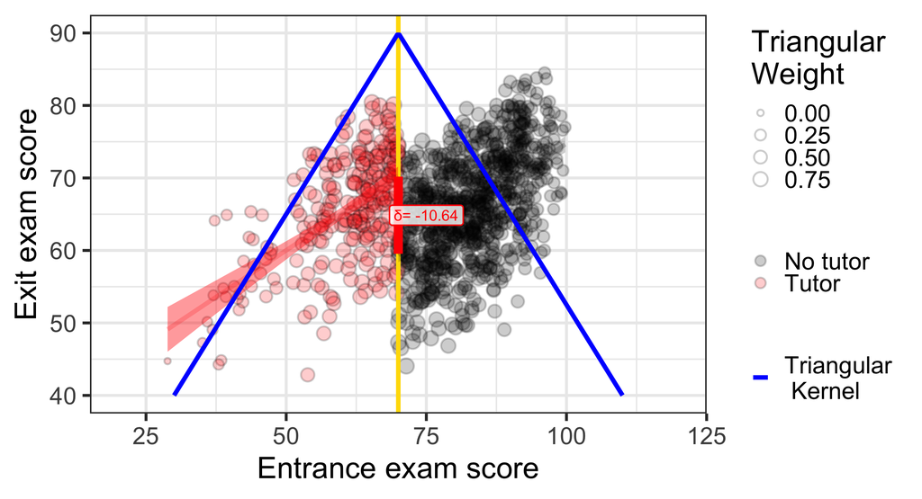

## Bandwidths

### Kernel: Epanechnikov

```r
kernel_df <- data.frame(
  entrance_exam = seq(cutoff - bandwidth, cutoff + bandwidth, length.out = 200)
)

u <- (kernel_df$entrance_exam - cutoff) / bandwidth
kernel_df$epa_weight <- ifelse(abs(u) <= 1, 0.75 * (1 - u^2), 0)
kernel_df$epa_weight_rescaled <- kernel_df$epa_weight * 50 + 40  # adjust as needed


# Compute Epanechnikov weights
tutoring$epa_weight <- with(tutoring, {
  u <- (entrance_exam - cutoff) / bandwidth
  ifelse(abs(u) <= 1, 0.75 * (1 - u^2), 0)
})

model4 <- lm(exit_exam ~ entrance_centered + tutoring,
             data = tutoring,
             weights = epa_weight)

x<-tidy(model4)
gap<-round(x$estimate[x$term=="tutoringFALSE"],2)
const<-round(x$estimate[x$term=="(Intercept)"],2)


ggplot()+
  geom_point(data = tutoring,
             aes(x = entrance_exam,
                 y = exit_exam,
                 fill = tutoring_text,
                 size = epa_weight),
             shape = 21,
             alpha = 0.2) +
  geom_vline(xintercept = 70, size = 2, color = "#FFDC00") +
  labs(x = "Entrance exam score", y = "Exit exam score") +
geom_smooth(
  data = filter(tutoring, entrance_exam <= 70),
  aes(x = entrance_exam, y = exit_exam),
  method = "lm",
  color = alpha("red", 0.2),        # line color
  fill = alpha("red", 0.2),          # confidence interval fill
  size = 2,
  show.legend = FALSE
) +
geom_smooth(
  data = filter(tutoring, entrance_exam > 70),
  aes(x = entrance_exam, y = exit_exam),
  method = "lm",
  color = alpha("black", 0.2),        # line color
  fill = alpha("black", 0.2),          # confidence interval fill
  alpha = 0.2,
  size = 2,
  show.legend = FALSE
) +
  scale_fill_manual(values = c("black", "red"), name = NULL) +
  scale_color_manual(values = c("black", "red")) +
  scale_size_continuous(name = "Epanechnikov\nWeight", range = c(2, 6)) +  # legend control
  theme_bw(base_size = 28)+
  annotate(geom = "segment", x = 70, xend = 70,
           y = const, yend = const + gap,
           size = 4, color = "red") +
    annotate(geom = "label", x = 75, y = const + (gap / 2),
           label = paste("δ=", gap),
           size=5,
           color = "red", fill = alpha(c("white"),0.8))+
  coord_cartesian(xlim = c(20, 120), ylim = c(40, 90)) +
  new_scale_color() +
  geom_line(
    data = kernel_df,
    aes(x = entrance_exam,
        y = epa_weight_rescaled,
        color = "Epanechnikov\n Kernel"), # <-- also mapped to show dashed line in legend
    inherit.aes = FALSE,
    size = 2
  )+
  scale_color_manual(name = NULL, values = c("Epanechnikov\n Kernel" = "blue"))+
  guides(
  size = guide_legend(order = 1),
  fill = guide_legend(order = 2),
  color = guide_legend(order = 3)
)
```

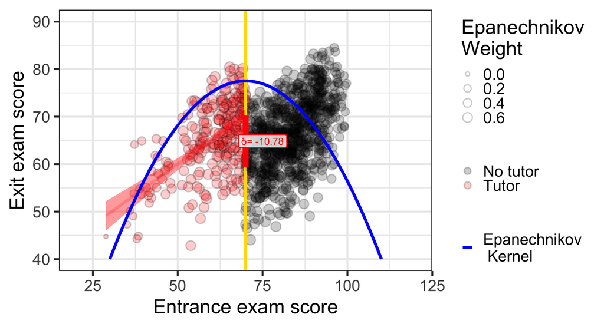

## Practical Advice

In the end there are several moving parts (bandwidth, kernel, order, etc.).

The best thing to do is to use `rdrobust` and present all the results.

## New

```r
# Uniform
# Run rdrobust with all results
rd1 <- rdrobust(y = tutoring$exit_exam, x = tutoring$entrance_exam, c = 70,
               kernel = "Uniform")
# Create a named list of models (each method with its estimate and se)
models <- list(
  "Conventional" = rd1$Estimate[1],
  "Bias-Corrected" = rd1$Estimate[2],
  "Robust Bias-Corrected" = rd1$Estimate[3]
)

ses <- list(
  "Conventional" = rd1$se[1],
  "Bias-Corrected" = rd1$se[2],
  "Robust Bias-Corrected" = rd1$se[3]
)

# Build a modelsummary-style data frame
library(tibble)


results1 <- tibble::tibble(
  Statistic = c("Estimate", "Std. Error", "Kernel", "Obs.", "Bandwidth"),
  `Conventional` = c(
    sprintf("%.3f", models$Conventional),
    sprintf("%.3f", ses$Conventional),
    rd1$kernel,  # keep as-is (a string)
    sum(rd1$N),
    sprintf("%.3f",rd1$bws[1])
  ),
  `Bias-Corrected` = c(
    sprintf("%.3f", models$`Bias-Corrected`),
    sprintf("%.3f", ses$`Bias-Corrected`),
    rd1$kernel,
    sum(rd1$N),
    sprintf("%.3f",rd1$bws[2])
  ),
  `Robust Bias-Corrected` = c(
    sprintf("%.3f", models$`Robust Bias-Corrected`),
    sprintf("%.3f", ses$`Robust Bias-Corrected`),
    rd1$kernel,
    sum(rd1$N),
    sprintf("%.3f",rd1$bws[2])
  )
)

#Triangular

# Run rdrobust with all results
rd2 <- rdrobust(y = tutoring$exit_exam, x = tutoring$entrance_exam, c = 70,
               kernel = "Triangular")
# Create a named list of models (each method with its estimate and se)
models <- list(
  "Conventional" = rd2$Estimate[1],
  "Bias-Corrected" = rd2$Estimate[2],
  "Robust Bias-Corrected" = rd2$Estimate[3]
)

ses <- list(
  "Conventional" = rd2$se[1],
  "Bias-Corrected" = rd2$se[2],
  "Robust Bias-Corrected" = rd2$se[3]
)

# Build a modelsummary-style data frame
library(tibble)


results2 <- tibble::tibble(
  Statistic = c("Estimate", "Std. Error", "Kernel", "Obs.", "Bandwidth"),
  `Conventional` = c(
    sprintf("%.3f", models$Conventional),
    sprintf("%.3f", ses$Conventional),
    rd2$kernel,  # keep as-is (a string)
    sum(rd2$N),
    sprintf("%.3f",rd2$bws[1])
  ),
  `Bias-Corrected` = c(
    sprintf("%.3f", models$`Bias-Corrected`),
    sprintf("%.3f", ses$`Bias-Corrected`),
    rd2$kernel,
    sum(rd2$N),
    sprintf("%.3f",rd2$bws[2])
  ),
  `Robust Bias-Corrected` = c(
    sprintf("%.3f", models$`Robust Bias-Corrected`),
    sprintf("%.3f", ses$`Robust Bias-Corrected`),
    rd2$kernel,
    sum(rd2$N),
    sprintf("%.3f",rd2$bws[2])
  )
)

#Epanechnikov

# Run rdrobust with all results
rd3 <- rdrobust(y = tutoring$exit_exam, x = tutoring$entrance_exam, c = 70,
               kernel = "Epanechnikov")
# Create a named list of models (each method with its estimate and se)
models <- list(
  "Conventional" = rd3$Estimate[1],
  "Bias-Corrected" = rd3$Estimate[2],
  "Robust Bias-Corrected" = rd3$Estimate[3]
)

ses <- list(
  "Conventional" = rd3$se[1],
  "Bias-Corrected" = rd3$se[2],
  "Robust Bias-Corrected" = rd3$se[3]
)

# Build a modelsummary-style data frame
library(tibble)


results3 <- tibble::tibble(
  Statistic = c("Estimate", "Std. Error", "Kernel", "Obs.", "Bandwidth"),
  `Conventional` = c(
    sprintf("%.3f", models$Conventional),
    sprintf("%.3f", ses$Conventional),
    rd3$kernel,  # keep as-is (a string)
    sum(rd1$N),
    sprintf("%.3f",rd3$bws[1])
  ),
  `Bias-Corrected` = c(
    sprintf("%.3f", models$`Bias-Corrected`),
    sprintf("%.3f", ses$`Bias-Corrected`),
    rd3$kernel,
    sum(rd1$N),
    sprintf("%.3f",rd3$bws[2])
  ),
  `Robust Bias-Corrected` = c(
    sprintf("%.3f", models$`Robust Bias-Corrected`),
    sprintf("%.3f", ses$`Robust Bias-Corrected`),
    rd3$kernel,
    sum(rd3$N),
    sprintf("%.3f",rd3$bws[2])
  )
)

# Create a separator row
separator_uniform <- tibble::tibble(
  Statistic = "<b>Uniform Kernel</b>",
  Conventional = "", `Bias-Corrected` = "", `Robust Bias-Corrected` = ""
)

separator_triangular <- tibble::tibble(
  Statistic = "<b>Triangular Kernel</b>",
  Conventional = "", `Bias-Corrected` = "", `Robust Bias-Corrected` = ""
)

separator_epanechnikov <- tibble::tibble(
  Statistic = "<b>Epanechnikov Kernel</b>",
  Conventional = "", `Bias-Corrected` = "", `Robust Bias-Corrected` = ""
)

results <- rbind(
  separator_uniform,
  results1,
  separator_triangular,
  results2,
  separator_epanechnikov,
  results3
)
# Show using modelsummary custom table
modelsummary::datasummary_df(results, output = "markdown")
```

| Statistic | Conventional | Bias-Corrected | Robust Bias-Corrected |
| --- | --- | --- | --- |
| **Uniform Kernel** |  |  |  |
| Estimate | -9.901 | -10.296 | 1.758 |
| Std. Error | 1.758 | 1.758 | 2.028 |
| Kernel | Uniform | Uniform | Uniform |
| Obs. | 1000 | 1000 | 1000 |
| Bandwidth | 5.648 | 10.607 | 10.607 |
| **Triangular Kernel** |  |  |  |
| Estimate | -9.992 | -10.228 | 1.708 |
| Std. Error | 1.708 | 1.708 | 2.049 |
| Kernel | Triangular | Triangular | Triangular |
| Obs. | 1000 | 1000 | 1000 |
| Bandwidth | 7.616 | 11.669 | 11.669 |
| **Epanechnikov Kernel** |  |  |  |
| Estimate | -9.897 | -10.097 | 1.686 |
| Std. Error | 1.686 | 1.686 | 2.018 |
| Kernel | Epanechnikov | Epanechnikov | Epanechnikov |
| Obs. | 1000 | 1000 | 1000 |
| Bandwidth | 7.066 | 11.389 | 11.389 |

## Limitations and Caveats

The gap at the cutoff is the LATE (Local Average Treatment Effect).

Thus, the findings have high internal validity and low external validity:

- the findings are limited in scope
- these are local empirical results

## Placebo Test

### Falsification via Fake Cutoffs

A **placebo test** checks for discontinuities at points **where no treatment should occur**.

It helps ensure that:

- The observed treatment effect at the true cutoff is **not an artifact** of underlying trends or model misspecification.
- There are **no jumps** in the outcome at **arbitrary thresholds**.

## Placebo Test

### Example Strategy

Re-run the RDD at other values of the running variable (e.g. 60, 65, 75, 80).

If $\delta$ is **non-zero** at those points, the original result may be spurious.

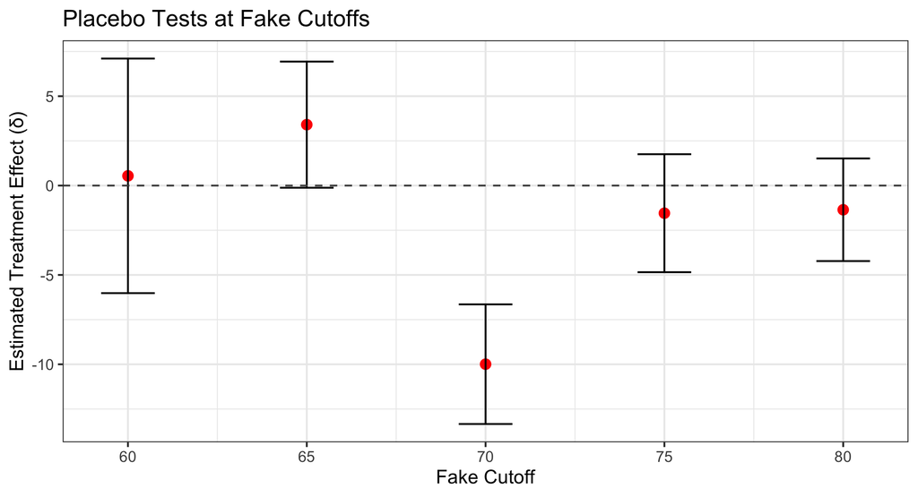

```r
library(purrr)
# Fake placebo cutoffs
placebo_cutoffs <- c(60, 65, 70, 75, 80)

# Store estimates
placebo_results <- map_dfr(placebo_cutoffs, function(cut) {
  fit <- rdrobust(y = tutoring$exit_exam, x = tutoring$entrance_exam, c = cut)

  tibble(
    cutoff = cut,
    estimate = fit$coef[1, 1],  # [row 1 = Conventional, column 1 = estimate]
    se = fit$se[1, 1]           # [row 1 = Conventional, column 1 = std error]
  )
})

ggplot(placebo_results, aes(x = cutoff, y = estimate)) +
  geom_point(size = 4, color = "red") +
  geom_errorbar(aes(ymin = estimate - 1.96 * se,
                    ymax = estimate + 1.96 * se),
                width = 1.5, color = "black") +
  geom_hline(yintercept = 0, linetype = "dashed", color = "gray30") +
  labs(title = "Placebo Tests at Fake Cutoffs",
       x = "Fake Cutoff",
       y = "Estimated Treatment Effect (δ)") +
  theme_bw(base_size = 18)
```

## Covariate Balance

### Are Subjects Comparable Around the Cutoff?

One key assumption of RDD is that **units just above and just below the cutoff are similar** in all aspects *except* treatment assignment. There is no precise manipulation at the cutoff.

This means **pre-treatment covariates** should be **balanced** across the threshold.

**Why It Matters**

- Helps validate the **continuity assumption**
- Suggests that **selection bias is unlikely**
- Strengthens causal interpretation of $\delta$

## Covariate Balance

### How to Test It

Run the same RDD logic, but use **pre-treatment covariates** as outcomes.

If there’s **no jump**, the assumption holds.

## Caveat 1

### Manipulation at the threshold

People might be aware of the cutoff so they might modify their behavior to get in/out of program

For example, students could try to get a slightly lower grade to benefit from the tutoring program.

This means that people at the cutoff are not representative of the control and treatment group.

## Caveat 1

### Manipulation Test

The way to test for manipulation at the cutoff is the McCrary density test.

This is an example of Non-manipulation

```r
library(dplyr)
set.seed(123)  # Set random seed for reproducibility
num_students <- 1000  # Number of simulated students

# Create a tibble (data frame) with simulated student data
tutoring <- tibble(
  id = 1:num_students,  # Unique ID for each student

  # Simulate entrance exam scores using a Beta distribution (scaled 0–100)
  entrance_exam = rbeta(num_students, shape1 = 7, shape2 = 2),

  # Simulate base ability for exit exam (before adding treatment effects)
  exit_exam_base = rbeta(num_students, shape1 = 5, shape2 = 3)
) |>
  mutate(
    entrance_exam = entrance_exam * 100,  # Convert entrance exam scores to 0–100 scale

    # Deterministic assignment rule:
    # Students with entrance_exam ≤ 70 are assigned to receive tutoring
    tutoring_assignment = entrance_exam <= 70,

    # Fuzzy compliance: not everyone follows their assignment perfectly
    tutoring_fuzzy = case_when(
      # 85% of assigned students actually take tutoring
      tutoring_assignment & runif(n()) < 0.85 ~ TRUE,
      # 15% of unassigned students take tutoring anyway
      !tutoring_assignment & runif(n()) < 0.15 ~ TRUE,
      # Everyone else does not take tutoring
      TRUE ~ FALSE
    ),

    # Construct the true exit exam score assuming tutoring has a positive effect
    # - Base score scaled to 0–40
    # - +10 points for being assigned tutoring
    # - +0.5 points per entrance exam point
    exit_exam = exit_exam_base * 40 + 10 * tutoring_assignment + entrance_exam / 2,

    # Same as above but using actual (fuzzy) tutoring status
    exit_exam_fuzzy = exit_exam_base * 40 + 10 * tutoring_fuzzy + entrance_exam / 2,

    # Label variables for clarity (for use in plots/tables)
    tutoring_text = factor(tutoring_assignment, levels = c(FALSE, TRUE), labels = c("No tutor", "Tutor")),
    tutoring_fuzzy_text = factor(tutoring_fuzzy, levels = c(FALSE, TRUE), labels = c("No tutor", "Tutor")),

    # Center entrance exam scores around 70 for regression interpretation
    entrance_centered = entrance_exam - 70
  )
```

```
[1] 1
```

[figure not shown]

## Caveat 1

### Manipulation Test

The way to test for manipulation at the cutoff is the McCrary density test.

This is an example of Manipulation

```r
set.seed(123)  # for reproducibility
num_students <- 1500  # a bit more to have room for thinning

tutoring2 <- tibble(
  id = 1:num_students,
  entrance_exam = rbeta(num_students, shape1 = 7, shape2 = 2),
  exit_exam = rbeta(num_students, shape1 = 5, shape2 = 3)
) |>
  mutate(entrance_exam = entrance_exam * 100) |>

  # 🔥 Add manipulation: fewer people just above the cutoff
  filter(!(entrance_exam > 70 & entrance_exam < 75 & runif(n()) < 0.5)) |>  # randomly drop 50% just above cutoff

  mutate(
    # Assignment
    tutoring_assignment = entrance_exam <= 70,

    # Fuzzy compliance
    tutoring_fuzzy = case_when(
      tutoring_assignment & runif(n()) < 0.85 ~ TRUE,
      !tutoring_assignment & runif(n()) < 0.15 ~ TRUE,
      TRUE ~ FALSE
    ),

    # Outcome
    exit_exam = exit_exam * 40 + 10 * tutoring_fuzzy + entrance_exam / 2,

    # Labels
    tutoring_text = factor(tutoring_assignment, levels = c(FALSE, TRUE), labels = c("No tutor", "Tutor")),
    tutoring_fuzzy_text = factor(tutoring_fuzzy, levels = c(FALSE, TRUE), labels = c("No tutor", "Tutor")),
    entrance_centered = entrance_exam - 70
  )


library(rddensity)
mtest <- rddensity(X = tutoring2$entrance_exam, c=70)
man<-rdplotdensity(mtest,X = tutoring2$entrance_exam)$Estplot+
  geom_vline(xintercept=70, linetype="dashed") +
  labs(x="Entrance exam score", y="Density")
```

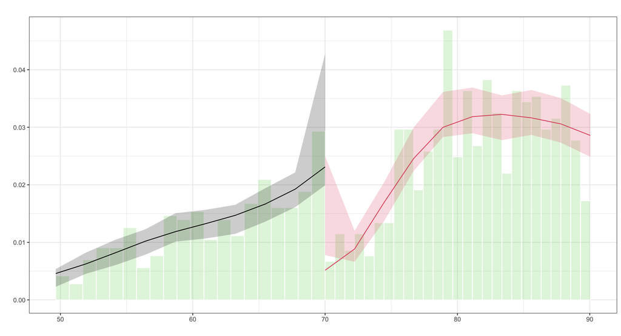

## Noncompliance

The logic for noncompliance means that people on the margin of the cutoff might end up in/out of the program.

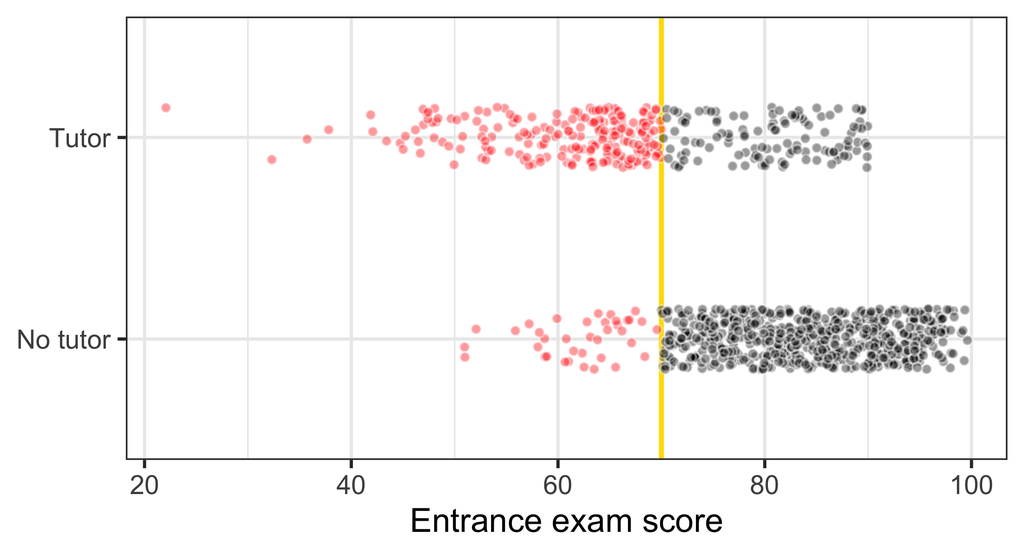

```r
ggplot(tutoring, aes(x = entrance_exam, y = tutoring_fuzzy_text, fill = entrance_exam <= 70)) +
  geom_vline(xintercept = 70, linewidth = 2, color = "#FFDC00") +
  geom_point(size = 3, pch = 21, color = "white", alpha = 0.4,
             position = position_jitter(width = 0, height = 0.15, seed = 1234)) +
  labs(x = "Entrance exam score", y = NULL) +
  guides(fill = "none") +
  scale_fill_manual(values = c("black", "red"), name = NULL) +
  theme_bw(base_size = 28)
```

## Compliance

The logic for noncompliance means that people on the margin of the cutoff might end up in/out of the program.

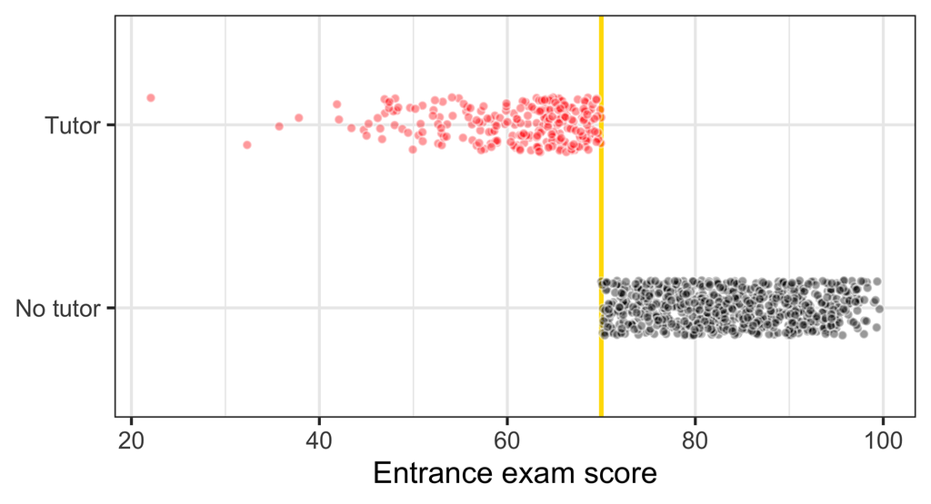

```r
ggplot(tutoring, aes(x = entrance_exam, y = tutoring_text, fill = tutoring_text)) +
  geom_vline(xintercept = 70, linewidth = 2, color = "#FFDC00") +
  geom_point(size = 3, pch = 21, color = "white", alpha = 0.4,
             position = position_jitter(width = 0, height = 0.15, seed = 1234)) +
  labs(x = "Entrance exam score", y = NULL) +
  guides(fill = "none") +
  scale_fill_manual(values = c("black", "red"), name = NULL) +
  theme_bw(base_size = 28)
```

## Noncompliance

### Addressing it

The way to address noncompliance is to use fuzzy discontinuities:

- Use an instrument for which side of the cutoff people should be on

Thus, the effect will only be for compliers near the cutoff

## Compliance

| **Person Type** | **If Assigned to Treatment** | **If Assigned to Control** |
| --- | --- | --- |
| **Complier** | Takes treatment | Does **not** take treatment |
| **Always-Taker** | Takes treatment | Takes treatment |
| **Never-Taker** | Does **not** take treatment | Does **not** take treatment |
| **Defier** | Does **not** take treatment | Takes treatment |

## Example

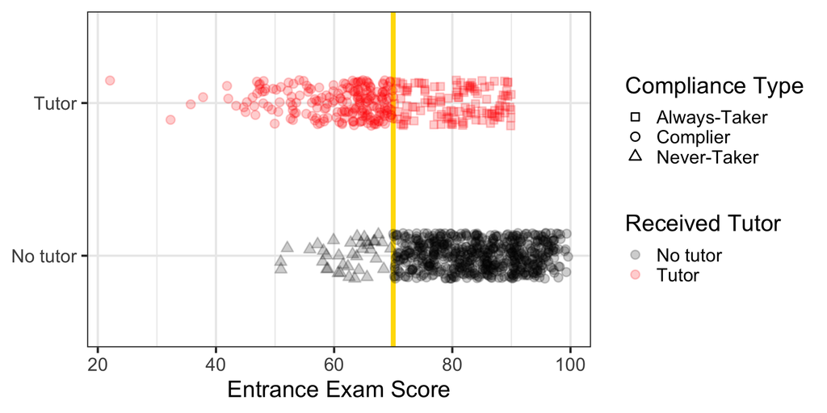

**Note**: We don’t include defiers because they would be students who do the exact opposite of the rule—refusing tutoring when they’re offered it and taking it when they’re not. In real life (and in our model), we assume people don’t usually behave that way.

## Noncompliance

### Addressing it

So, we can use an instrument = above/below cutoff to address non-compliance

The instrument has to meet three important criteria

- Relevance
  - The cutoff changes the likelihood of receiving the treatment.  
    → People below the cutoff are more likely to get tutoring.
- Exclusion
  - The cutoff affects the outcome *only through* the treatment.  
    → Crossing the threshold doesn’t directly change the outcome except by changing tutoring status.
- Exogeneity
  - Unobserved confounders between the tutoring program and exit exam scores are unrelated to the cutoff.

## Noncompliance

### Addressing it

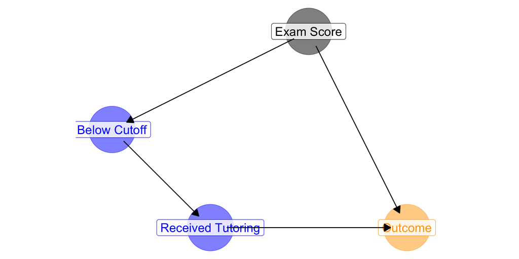

## Noncompliance

### Addressing it

The way to deal with noncompliance is to use a Fuzzy RD

We can do it in the following way:

```r
rdrobust(y = tutoring$exit_exam, x = tutoring$entrance_exam,
         c = 70, fuzzy = tutoring$tutoring_fuzzy)
```

[output not shown]

## Noncompliance

### Addressing it

Uniform Kernel

```r
# Uniform
# Run rdrobust with all results
rd1 <- rdrobust(y = tutoring$exit_exam, x = tutoring$entrance_exam, c = 70,
                fuzzy = tutoring$tutoring_fuzzy,
               kernel = "Uniform")
# Create a named list of models (each method with its estimate and se)
models <- list(
  "Conventional" = rd1$Estimate[1],
  "Bias-Corrected" = rd1$Estimate[2],
  "Robust Bias-Corrected" = rd1$Estimate[3]
)

ses <- list(
  "Conventional" = rd1$se[1],
  "Bias-Corrected" = rd1$se[2],
  "Robust Bias-Corrected" = rd1$se[3]
)

# Build a modelsummary-style data frame
library(tibble)


results1 <- tibble::tibble(
  Statistic = c("Estimate", "Std. Error", "Kernel", "Obs.", "Bandwidth"),
  `Conventional` = c(
    sprintf("%.3f", models$Conventional),
    sprintf("%.3f", ses$Conventional),
    rd1$kernel,  # keep as-is (a string)
    sum(rd1$N),
    sprintf("%.3f",rd1$bws[1])
  ),
  `Bias-Corrected` = c(
    sprintf("%.3f", models$`Bias-Corrected`),
    sprintf("%.3f", ses$`Bias-Corrected`),
    rd1$kernel,
    sum(rd1$N),
    sprintf("%.3f",rd1$bws[2])
  ),
  `Robust Bias-Corrected` = c(
    sprintf("%.3f", models$`Robust Bias-Corrected`),
    sprintf("%.3f", ses$`Robust Bias-Corrected`),
    rd1$kernel,
    sum(rd1$N),
    sprintf("%.3f",rd1$bws[2])
  )
)

#Triangular

# Run rdrobust with all results
rd2 <- rdrobust(y = tutoring$exit_exam, x = tutoring$entrance_exam, c = 70,
                                fuzzy = tutoring$tutoring_fuzzy,
               kernel = "Triangular")
# Create a named list of models (each method with its estimate and se)
models <- list(
  "Conventional" = rd2$Estimate[1],
  "Bias-Corrected" = rd2$Estimate[2],
  "Robust Bias-Corrected" = rd2$Estimate[3]
)

ses <- list(
  "Conventional" = rd2$se[1],
  "Bias-Corrected" = rd2$se[2],
  "Robust Bias-Corrected" = rd2$se[3]
)

# Build a modelsummary-style data frame
library(tibble)


results2 <- tibble::tibble(
  Statistic = c("Estimate", "Std. Error", "Kernel", "Obs.", "Bandwidth"),
  `Conventional` = c(
    sprintf("%.3f", models$Conventional),
    sprintf("%.3f", ses$Conventional),
    rd2$kernel,  # keep as-is (a string)
    sum(rd2$N),
    sprintf("%.3f",rd2$bws[1])
  ),
  `Bias-Corrected` = c(
    sprintf("%.3f", models$`Bias-Corrected`),
    sprintf("%.3f", ses$`Bias-Corrected`),
    rd2$kernel,
    sum(rd2$N),
    sprintf("%.3f",rd2$bws[2])
  ),
  `Robust Bias-Corrected` = c(
    sprintf("%.3f", models$`Robust Bias-Corrected`),
    sprintf("%.3f", ses$`Robust Bias-Corrected`),
    rd2$kernel,
    sum(rd2$N),
    sprintf("%.3f",rd2$bws[2])
  )
)

#Epanechnikov

# Run rdrobust with all results
rd3 <- rdrobust(y = tutoring$exit_exam, x = tutoring$entrance_exam, c = 70,
                                fuzzy = tutoring$tutoring_fuzzy,
               kernel = "Epanechnikov")
# Create a named list of models (each method with its estimate and se)
models <- list(
  "Conventional" = rd3$Estimate[1],
  "Bias-Corrected" = rd3$Estimate[2],
  "Robust Bias-Corrected" = rd3$Estimate[3]
)

ses <- list(
  "Conventional" = rd3$se[1],
  "Bias-Corrected" = rd3$se[2],
  "Robust Bias-Corrected" = rd3$se[3]
)

# Build a modelsummary-style data frame
library(tibble)


results3 <- tibble::tibble(
  Statistic = c("Estimate", "Std. Error", "Kernel", "Obs.", "Bandwidth"),
  `Conventional` = c(
    sprintf("%.3f", models$Conventional),
    sprintf("%.3f", ses$Conventional),
    rd3$kernel,  # keep as-is (a string)
    sum(rd1$N),
    sprintf("%.3f",rd3$bws[1])
  ),
  `Bias-Corrected` = c(
    sprintf("%.3f", models$`Bias-Corrected`),
    sprintf("%.3f", ses$`Bias-Corrected`),
    rd3$kernel,
    sum(rd1$N),
    sprintf("%.3f",rd3$bws[2])
  ),
  `Robust Bias-Corrected` = c(
    sprintf("%.3f", models$`Robust Bias-Corrected`),
    sprintf("%.3f", ses$`Robust Bias-Corrected`),
    rd3$kernel,
    sum(rd3$N),
    sprintf("%.3f",rd3$bws[2])
  )
)

# Create a separator row

separator_fs <- tibble::tibble(
  Statistic = "<b>First stage</b>",
  Conventional = "", `Bias-Corrected` = "", `Robust Bias-Corrected` = ""
)

separator_ss <- tibble::tibble(
  Statistic = "<b>Treatment effect estimates</b>",
  Conventional = "", `Bias-Corrected` = "", `Robust Bias-Corrected` = ""
)

separator_uniform <- tibble::tibble(
  Statistic = "<b>Uniform Kernel</b>",
  Conventional = "", `Bias-Corrected` = "", `Robust Bias-Corrected` = ""
)

separator_triangular <- tibble::tibble(
  Statistic = "<b>Triangular Kernel</b>",
  Conventional = "", `Bias-Corrected` = "", `Robust Bias-Corrected` = ""
)

separator_epanechnikov <- tibble::tibble(
  Statistic = "<b>Epanechnikov Kernel</b>",
  Conventional = "", `Bias-Corrected` = "", `Robust Bias-Corrected` = ""
)



# First-stage estimates
first_stage_rd1 <- tibble::tibble(
  Statistic = c("Estimate", "Std. Error"),
  `Conventional` = c(
    sprintf("%.3f", rd1$tau_T[1]),
    sprintf("%.3f", rd1$se_T[1])),

  `Bias-Corrected` = c(
    sprintf("%.3f", rd1$tau_T[2]),
    sprintf("%.3f", rd1$se_T[2])),

  `Robust Bias-Corrected` = c(
    sprintf("%.3f", rd1$tau_T[3]),
    sprintf("%.3f", rd1$se_T[3]))
)


# First-stage estimates
first_stage_rd2 <- tibble::tibble(
  Statistic = c("Estimate", "Std. Error"),
  `Conventional` = c(
    sprintf("%.3f", rd2$tau_T[1]),
    sprintf("%.3f", rd2$se_T[1])),

  `Bias-Corrected` = c(
    sprintf("%.3f", rd2$tau_T[2]),
    sprintf("%.3f", rd2$se_T[2])),

  `Robust Bias-Corrected` = c(
    sprintf("%.3f", rd2$tau_T[3]),
    sprintf("%.3f", rd2$se_T[3]))
)

# First-stage estimates
first_stage_rd3 <- tibble::tibble(
  Statistic = c("Estimate", "Std. Error"),
  `Conventional` = c(
    sprintf("%.3f", rd3$tau_T[1]),
    sprintf("%.3f", rd3$se_T[1])),

  `Bias-Corrected` = c(
    sprintf("%.3f", rd3$tau_T[2]),
    sprintf("%.3f", rd3$se_T[2])),

  `Robust Bias-Corrected` = c(
    sprintf("%.3f", rd3$tau_T[3]),
    sprintf("%.3f", rd3$se_T[3]))
)

results_final1 <- rbind(
  separator_uniform,
  separator_fs,
  first_stage_rd1,
  separator_ss,
  results1)

results_final2 <- rbind(separator_triangular,
  separator_fs,
  first_stage_rd2,
  separator_ss,
  results2)

results_final3 <- rbind(separator_epanechnikov,
  separator_fs,
  first_stage_rd3,
  separator_ss,
  results3)

# Show using modelsummary custom table
modelsummary::datasummary_df(results_final1, output = "markdown")
```

| Statistic | Conventional | Bias-Corrected | Robust Bias-Corrected |
| --- | --- | --- | --- |
| **Uniform Kernel** |  |  |  |
| **First stage** |  |  |  |
| Estimate | -0.633 | -0.625 | -0.625 |
| Std. Error | 0.092 | 0.092 | 0.110 |
| **Treatment effect estimates** |  |  |  |
| Estimate | 18.112 | 18.512 | 4.144 |
| Std. Error | 4.144 | 4.144 | 4.984 |
| Kernel | Uniform | Uniform | Uniform |
| Obs. | 1000 | 1000 | 1000 |
| Bandwidth | 6.123 | 10.533 | 10.533 |

## Noncompliance

### Addressing it

Triangular Kernel

```r
# Show using modelsummary custom table
modelsummary::datasummary_df(results_final2, output = "markdown")
```

| Statistic | Conventional | Bias-Corrected | Robust Bias-Corrected |
| --- | --- | --- | --- |
| **Triangular Kernel** |  |  |  |
| **First stage** |  |  |  |
| Estimate | -0.680 | -0.699 | -0.699 |
| Std. Error | 0.072 | 0.072 | 0.087 |
| **Treatment effect estimates** |  |  |  |
| Estimate | 16.644 | 16.644 | 2.899 |
| Std. Error | 2.899 | 2.899 | 3.546 |
| Kernel | Triangular | Triangular | Triangular |
| Obs. | 1000 | 1000 | 1000 |
| Bandwidth | 13.090 | 19.608 | 19.608 |

## Noncompliance

### Addressing it

Epanechnikov Kernel

```r
# Show using modelsummary custom table
modelsummary::datasummary_df(results_final3, output = "markdown")
```

| Statistic | Conventional | Bias-Corrected | Robust Bias-Corrected |
| --- | --- | --- | --- |
| **Epanechnikov Kernel** |  |  |  |
| **First stage** |  |  |  |
| Estimate | -0.660 | -0.672 | -0.672 |
| Std. Error | 0.077 | 0.077 | 0.092 |
| **Treatment effect estimates** |  |  |  |
| Estimate | 17.159 | 17.440 | 3.214 |
| Std. Error | 3.214 | 3.214 | 3.902 |
| Kernel | Epanechnikov | Epanechnikov | Epanechnikov |
| Obs. | 1000 | 1000 | 1000 |
| Bandwidth | 10.779 | 16.937 | 16.937 |

## Summary: Regression Discontinuity Design

**Goal**:  
Estimate **local causal effect** of treatment at a known cutoff using a continuous running variable.

**Key Assumptions**:  
- **Continuity**: Potential outcomes $Y(0)$ and $Y(1)$ change smoothly at the cutoff.  
- **No Precise Manipulation**: Units cannot perfectly sort just above or below the cutoff.

**Diagnostics & Robustness**:  
- **McCrary Test**: Check for manipulation in the running variable’s density.  
- **Covariate Balance**: No jumps in pre-treatment covariates at cutoff.  
- **Placebo Tests**: No effects at fake cutoffs.

**Interpretation**:  
- Estimate is **Local Average Treatment Effect (LATE)** at the cutoff.  
- RDD is valid **only near the cutoff**—not population-wide.